# Calibrating the baseline of arm `revised`: what was tried, what worked, and where it stands

Four attempts to calibrate a stable baseline failed; one worked. e is now derived from the data, and a single unobserved portfolio share makes the baseline stationary. What remains is the debt level and the fit of the real economy.

Author

LEEDS_MODEL — JUST2CE

Published

September 28, 2026

**Written:** 2026-09-28 · **Repo at:** `main` @ `d6f2f4a` (+ the evidence scripts committed with this report)

**Read from:** - **Evidence CSVs, all under `output/calibration/`, written 2026-09-28:** - `enterprise_premium_20260928.csv`, from `R/calibrate_enterprise_premium.R`; - `revised_cab_search_20260928.csv`, from `R/calibrate_revised_cab.R`; - `revised_baseline_stats_20260928.csv`, `revised_fitness_20260928.csv` and `revised_fitness_cells_20260928.csv`, from `R/revised_calibration_evidence.R`, which reads the cached 100-period baselines of `submitted`, `sraffian` and `revised`. - **The earlier calibration record:** - `qmd/reports/2026-09-27-calibration-search-trajectory.qmd` and its `trail.csv`; - `qmd/reports/2026-09-26-sraffian-baseline-calibration.qmd`; - `qmd/reports/2026-09-26-stability-structure.qmd`; - `qmd/reports/2026-09-28-calibration-per-draw-visualization.qmd`; - `qmd/reports/2026-09-28-sraffian-stability-review.md`. - `log/session_20260928.md`.

**Status of claims:** - Every table below is read from those CSVs when this document renders, and the CSVs were written from model runs made on 2026-09-28. - Statements about the 2026-09-26 and 2026-09-27 work are **quoted from those reports**, not re-measured; they are marked *(quoted)*. - Interpretation is labelled as such.

## What this is about

The object is the **baseline of arm `revised`**: the unshocked 100-period run that all fourteen circular-economy scenarios are measured against. The report covers every attempt made between 2026-09-26 and 2026-09-28 to calibrate a baseline that is both **stable** and **close to the data**.

- **Stable** means that debt/value added and the other stock–flow ratios settle, instead of compounding or drifting.
- **Close to the data** means close to the 24 target cells in `data/target_values.xlsx`.

The outcome in one paragraph: - **Four attempts on arm `sraffian` failed.** They aimed at the wrong object: the fiscal parameters and an interest–growth objective. The instability actually came from two things the fiscal parameters cannot reach: the model’s closure between the two central banks, and its zero-stock initial state. - **Arm `revised` fixed that structure** (2026-09-28). - **Two calibration steps then made the baseline stationary:** - deriving the enterprise premium `e` from the data; - setting one unobserved portfolio share so that the EU current account is zero. - **What remains:** - the **debt level**, which is now path-dependent: EU 0.10 and RoW 1.72 of value added, against targets of 0.81 and 0.85; - a **real economy about 20–30% below target**.

## Background the reader may not have

**Arms.** An *arm* is one row of `data/arms.csv`: a named configuration of the model’s specification switches. - `submitted` reproduces the paper as submitted on 2026-04-03. - `sraffian` replaces the sectoral markups with a uniform-profit-rate price of production. - `revised` is `sraffian` plus eight structural changes (R1–R8, switch `revision_spec`), specified in `qmd/reports/2026-09-28-sraffian-stability-review.md`.

**Spin-up.** Every workbook starts all financial and real stocks at zero. Arm `revised` therefore runs the unshocked model for 60 periods and restarts from its last state (change R8), so its t = 1 is a mature economy.

**The fitness scalar.** `calib_fitness()` in `R/calibration_2026.R` measures fit to the data: - it compares the model with the 24 target cells (12 concepts × 2 regions) of `data/target_values.xlsx`; - each deviation is taken as a fraction of the region’s value-added target (`scale = "gdp"`), and nominal cells are deflated; - it returns the mean squared deviation, so **lower is better**. It is the scalar the 2026-09-27 random search minimised.

**Stationary vs stable.** A baseline can be stable (no explosive root) and still drift: a constant deficit makes debt grow *linearly*. *Stationary* here means both. The test used is that debt/VA changes by less than 0.002 per period over t = 75–100.

## The calibration attempts, in order

### 1. Random search on the fit, arm `sraffian` (2026-09-27) *(quoted)*

- **Search:** `R/calibrate_random_search.R` drew tax rates, propensities and markups and kept any draw that lowered the fitness scalar and completed 100 periods.
- **Result:** fitness fell from 0.8094 to 0.0294 over 500 draws, 11 of them accepted, then plateaued near 1.5× `submitted`’s fit.
- **Limitation:** the scalar is a snapshot at t = 100 and contains no stability condition, so a run whose debt passed through the target at t = 100 while diverging scored well.

### 2. Five fiscal levers, arm `sraffian` (2026-09-26) *(quoted)*

- **Levers swept** (`2026-09-26-sraffian-baseline-calibration.qmd`): wage drift, a lump-sum tax rule, a tax-rate rule, spending growth and the spending level.
- **Result:** no single lever brought debt growth to about one.
- **An incidence defect in the tax-rate rule.** The rule raised the tax *revenue* on wages, but worker disposable income was computed with the frozen rate, so the whole rise fell on capitalist income. Fixed 2026-09-28 (`2026-09-28-tax-rate-fiscal-rule-incidence.qmd`).

### 3. Eight fiscal-rule seeds with a debt bound, arm `sraffian` (2026-09-28) *(quoted)*

- **Setup:** random searches over tax, propensity, rate and fiscal-rule instruments, rejecting any draw that failed the debt bound.
- **Result:** across eight seeds and 1,000 draws, **none was accepted**, so the incumbent never moved from its start (`2026-09-28-calibration-per-draw-visualization.qmd`).
- **Stale setting:** the seeds had also been launched with the Armington elasticity at 0, which the arm no longer uses.

### 4. The interest-rate–growth objective, and its retraction (2026-09-26 → 2026-09-28)

- **The 2026-09-26 report** `2026-09-26-stability-structure.qmd` diagnosed:
  - the debt block as a diagonal 2 × 2 system with a root of 1 + r_b per region;
  - the debt/VA ratio as compounding at (1 + r_b)/(1 + g);
  - the portfolio shares as irrelevant to it.
- **That report proposed** making (1 + r_b)/(1 + g) the search objective. That is why attempt 3 searched over interest rates.
- **The diagnosis was retracted** on 2026-09-28; see *What changed* below. Attempts 1–3 were therefore aimed at the fiscal parameters, while the instability sat elsewhere.

### 5. Arm `revised`: structural fixes, then two calibration steps (2026-09-28)

- **Structural fixes (R1–R8)** removed three things:
  - the RoW treasury → EU central bank → EU treasury interest circuit, which carried 81% of the EU deficit in `sraffian` at t = 100;
  - negative central-bank bill holdings;
  - the zero-stock start-up transient.
- **What that left:** a constant EU current-account deficit of −19 per period, settled in gold under the fixed exchange rate. Debt then grew linearly, not exponentially.
- **The two calibration steps that followed** are the subject of the next section.

## What was found

### Step 1: the enterprise premium e is derived, not chosen

**Why e cannot be free.** In the price of production

*p** = ℓ + (1 + *r*) · *p** (*A* + *D*),

- the technology (A, D) and the uniform rate r fix all relative prices;
- the money wage fixes their level;
- the labour cost per unit of output ℓ is data: in the workbook `w/pr` equals Wages/GO from the MRIO to within 4.6e-15.

Under the Sraffa–Pivetti closure used by `revised`, r = i + e: the money rate of interest plus the normal profit of enterprise. The data wage, the policy rate and e cannot all be set independently.

**What the old value rested on.** e was 0.233474, chosen to reproduce r = 0.3889 × R under the **diagonal** depreciation matrix that change R4 replaced. It therefore had no basis in `revised`.

**The new condition (P).** The prices of production must reproduce the observed price level at the observed output mix:

Σ<sub>*j*</sub> *p**<sub>*j*</sub>(*r*) · *x*<sub>*j*</sub><sup>obs</sup> = Σ<sub>*j*</sub> *x*<sub>*j*</sub><sup>obs</sup> (EXIOBASE 2011, basic prices = 1).

The table also reports the r at which the aggregate profit share at p* equals the observed share, (CFC + operating surplus) / (wages + CFC + OS) = 0.4296: condition S.

Derivation of e. i = 0.021655 (the VA-weighted bill rate); R = 0.603622 (the maximum rate of profit with D = ι d′).

| labour cost | r (condition P) | r (condition S) | e = r − i | π_std = r/R |
| --- | --- | --- | --- | --- |
| regional mean wage (6.9a, as run) | 0.245461 | 0.213176 | 0.223806 | 0.4066 |
| sectoral wages (data) | 0.259922 | 0.216478 | 0.238267 | 0.4306 |

- **Calculated:** under the regional mean wage the engine actually uses, condition P gives **r = 0.2455, so e = 0.223806**. That value is now in the workbook (`global.pars e`).
- **Observed: the two conditions disagree** (0.245 against 0.213). *Interpretation:* observed prices are not prices of production, because observed profit rates are not uniform, so no single r reproduces both the price level and the profit share. Condition P is used because it keeps every nominal flow and stock in the data’s units.
- **Observed: the uniform wage costs 1.4 points of r.** With the 54 sectoral wages r would be 0.2599. That gap measures what the one-wage-per-region idealisation (equation 6.9a) costs.

### Step 2: a zero EU current account from the one unobserved cross-border share (route A)

**Where the deficit came from.** After step 1, the EU’s current-account deficit was about half trade and half net dividends paid abroad. - **Trade shares** come from the MRIO. They are data and were not touched. - **The EU’s share of wealth held in RoW equity** (`lambdaE0_2`, EU holder) is 0.02 in the workbook and has never been estimated, so it is the parameter to calibrate.

**Keeping the other arms unchanged.** The workbook is shared with arms `lambda` and `sraffian`, which must not move. The calibrated value is therefore written as an **override row**, `lambdaE0_2__revised`, which `run.model()` substitutes only when `revision_spec = revised`.

**The search.** `R/calibrate_revised_cab.R` ran `revised` for 60 periods after the spin-up at eight values of the share. Each run records the EU current account averaged over its last 25 periods.

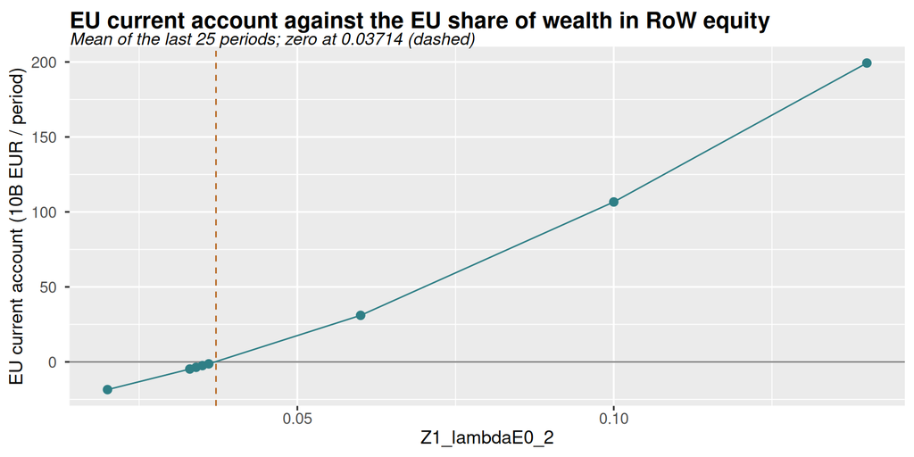

The search (60 periods after the spin-up; means over the last 25).

| EU share in RoW equity | EU CAB | EU trade balance | EU debt/VA slope |
| --- | --- | --- | --- |
| 0.020 | -18.48 | -10.21 | 0.02122 |
| 0.033 | -4.77 | -16.93 | 0.00525 |
| 0.034 | -3.63 | -17.49 | 0.00395 |
| 0.035 | -2.48 | -18.05 | 0.00265 |
| 0.036 | -1.31 | -18.62 | 0.00134 |
| 0.060 | 31.04 | -34.46 | -0.03312 |
| 0.100 | 106.65 | -71.04 | -0.09948 |
| 0.140 | 199.30 | -115.61 | -0.16011 |

- **Calculated:** a linear fit over 0.033–0.036 (R² = 0.99997) puts the zero at **0.03714**. The override is set to 0.03714.
- **Observed:** the trade balance worsens as the share rises. More dividend income raises EU imports, so the zero is reached with a trade deficit of about −19 financed by about +19 of net dividend income.

### Step 3: a gold endowment (inert)

- **Change:** gold reserves are now written in flow form, with each central bank starting from 1,500 (`gold_endowment`, its initial net worth).
- **Observed:** in the recut baseline it moved `Z1_or` and `Z2_or` by exactly +1,500 and no other cell. Without it, RoW gold sat at −1,062 after the spin-up.

## Where the baseline stands now

Path statistics of the three reference baselines (100 periods).

| arm | region | debt/VA t=75 | debt/VA t=100 | debt/VA slope | VA growth/period | CAB (mean, last 25) | gold t=100 |
| --- | --- | --- | --- | --- | --- | --- | --- |
| submitted | Z1 | 0.982 | 0.875 | -4.31e-03 | -1.93e-06 | 5.23 | 0 |
| submitted | Z2 | 1.138 | 1.166 | 1.13e-03 | 1.07e-05 | -5.23 | 0 |
| sraffian | Z1 | 2.380 | 3.108 | 2.94e-02 | 9.92e-05 | -32.70 | 0 |
| sraffian | Z2 | 1.422 | 1.199 | -9.05e-03 | 1.59e-04 | 32.70 | 0 |
| revised | Z1 | 0.101 | 0.104 | 1.24e-04 | -9.64e-06 | -0.17 | 2,561 |
| revised | Z2 | 1.720 | 1.720 | -5.43e-06 | 1.38e-05 | 0.17 | 438 |

- **Observed: `revised` is stationary.** The debt/VA slopes are 1.2e-04 (EU) and -5.4e-06 (RoW) per period. By comparison, `sraffian` has +0.029 (EU) and −0.009 (RoW), and `submitted` −0.004 and +0.001.
- **Observed: value added is flat**, and the EU current account averages -0.17 over t = 75–100.

Fit to the 24 data targets (mean squared deviation as a share of the VA target; lower is better).

|  | arm | fitness at t = 75 | fitness at t = 100 |
| --- | --- | --- | --- |
| 1 | submitted | 0.0209 | 0.0194 |
| 3 | sraffian | 0.1898 | 0.3631 |
| 5 | revised | 0.1133 | 0.1129 |

The eight largest contributions to revised’s misfit at t = 100.

| target | data | model | model / data | share of misfit (%) |
| --- | --- | --- | --- | --- |
| Z2_debt_gdp | 0.85 | 1.72 | 2.024 | 27.9 |
| Z1_b_s | 876.03 | 93.21 | 0.106 | 19.3 |
| Z1_debt_gdp | 0.81 | 0.10 | 0.128 | 18.4 |
| Z2_go | 8,424.52 | 6,048.07 | 0.718 | 13.5 |
| Z2_b_s | 3,345.25 | 5,219.86 | 1.560 | 8.4 |
| Z1_go | 2,153.60 | 1,774.42 | 0.824 | 4.5 |
| Z2_fd | 3,918.29 | 2,989.36 | 0.763 | 2.1 |
| Z2_va | 3,935.58 | 3,034.75 | 0.771 | 1.9 |

- **Calculated: fit.** `revised` scores 0.1129 at t = 100, against `sraffian` 0.3631 and `submitted` 0.0194.
- **Calculated: most of the misfit is debt.** Debt/VA in both regions plus the EU bill stock make up 65.7% of it:
  - EU debt/VA is 0.104 against a target of 0.81;
  - RoW debt/VA is 1.720 against 0.85.
- **Calculated: the rest is real output.** Gross output is about 0.72 of target in RoW and 0.82 in the EU.

**The EU central bank holds −240 of its own bills.** - **Why:** with EU debt at about 93, private demand for EU bills (households 169, RoW households 61, banks 103) exceeds the supply. - **The balance sheet closes:** 2,561 gold = 56 cash + 765 bank reserves + 240 bills + 1,500 net worth. - *Interpretation:* the −240 is central-bank sterilisation bills. It is not an accounting leak, but it is not a position a calibrated baseline should rest on.

## What changed, and why the earlier account was wrong

1. **The stability diagnosis.**
   - *Previous claim* (`2026-09-26-stability-structure.qmd`): the debt block has one root of 1 + r_b per region, the two regions are not coupled, the portfolio shares are orthogonal to the debt, and the objective should be (1 + r_b)/(1 + g).
   - *Evidence:* the report’s finite difference perturbs the bill stock alone. That creates bills no one holds, so a root of 1 + r_b follows by construction; the 2026-09-11 report had already set this direction aside as an accounting residue. The actual `sraffian` debt was driven by the reserve-interest circuit (81% of the EU deficit at t = 100), by a −1,611 EU central-bank position in RoW bills, and by the zero-stock start. Value added grows by about 0.01% per period at the horizon, so the 1.02% “g” was the transient.
   - *Corrected claim:* the instability was structural (the closure and the initial state), not fiscal.
   - *Consequence:* the (1 + r_b)/(1 + g) objective is retired, and the eight fiscal-rule seeds are not to be relaunched.
2. **The portfolio shares.**
   - *Previous claim:* the λ’s are orthogonal to the debt map.
   - *Evidence:* zeroing the cross-border equity shares in `revised` cut the EU current-account deficit and budget deficit by 32% (`output/calibration/revised_lambda_sensitivity_20260928.csv`); route A then zeroed the current account with one equity share.
   - *Corrected claim:* the equity shares set half of the external balance.
   - *Consequence:* they are calibration instruments, not inert parameters.
3. **e.**
   - *Previous claim:* e = 0.233474 reproduces the profit rate.
   - *Evidence:* it reproduced r = 0.3889 × R under the diagonal D, which `revised` no longer uses.
   - *Corrected claim:* e = 0.223806, derived from the price-level condition.
   - *Consequence:* r goes from 25.51% to 24.55%, and π_std from 0.4227 to 0.4066.

## What it means

*Interpretation.*

- **Every earlier attempt pulled levers that could not reach the problem.** Four approaches in three days adjusted fiscal parameters or searched against a fit or interest–growth objective, while the instability sat in the central-bank closure and the initial state.
- **Once the structure was fixed, one calibration step was enough.** Setting one never-estimated portfolio share turned a linear drift into a stationary baseline.
- **That exposes a property of the model worth stating in the paper.** With the current account and private net lending both zero, the government budget balances, so *any* debt level is a steady state. The level is set by history (here, the spin-up), not by the parameters. So the debt target cannot be reached by a parameter search; it has to be steered during the spin-up.
- **The fit now splits into two independent problems:** the debt level (about 70% of the misfit) and the scale of the real economy (most of the rest).

## Limits and what is not established

- **The zero current account is a composition as well as a balance.** It is about −19 in trade against about +19 in net dividend income. ⚠️ UNCERTAIN whether the EU’s 2011 balance of payments looks like that; it has to be checked before the paper relies on it.
- **Condition P versus condition S is a choice.** The report shows both, and they give r = 0.245 and 0.213 respectively.
- **The search ran 60 post-spin-up periods.** The final 100-period baseline confirms the zero (−0.17 mean over t = 75–100), but the exact root at 100 periods was not re-solved.
- **Several values are choices, not estimates:** `bank_bill_ratio` = 0.1, `spinup_periods` = 60 and `gold_endowment` = 1,500. The endowment is inert by construction; the other two are not.
- **Verification of the per-arm engine files:** only the 12-period fold test was run for `revised`.
- **The scenarios have not been run on `revised`.** They will move the current account away from zero, and there is no reserve rule yet to absorb that.

## Where this leaves things

These are options, not orders.

1. **Steer the debt level during the spin-up.** A fiscal rule that is active only in the 60 spin-up periods would drive debt/VA toward 0.81 (EU) and 0.85 (RoW) and switch off at t = 1. This addresses about 70% of the misfit and would also remove the EU central bank’s negative bill position. It is `log/NEXT_SESSION.md` item 3.
2. **Close the real-output gap** (RoW 0.72, EU 0.82 of target), via the propensities or the scale of autonomous demand, re-scored with the same fitness scalar.
3. **Check the current-account composition** against the EU’s 2011 balance of payments.
4. **Choose the reserve rule for the scenarios.** Godley–Lavoie *OPENFIXR* adjusts the bill rate and *OPENFIXG* adjusts government spending in response to reserve loss. This is a theoretical choice and the maintainer’s.
5. **Replace ι d′ with the Södersten–Lenzen capital-flow matrix.** This changes R and therefore e, so e must be re-derived afterwards with `R/calibrate_enterprise_premium.R --write`.

**Sources:** - Evidence files: `output/calibration/enterprise_premium_20260928.csv` · `output/calibration/revised_cab_search_20260928.csv` · `output/calibration/revised_baseline_stats_20260928.csv` · `output/calibration/revised_fitness_20260928.csv` · `output/calibration/revised_fitness_cells_20260928.csv` · `output/calibration/revised_lambda_sensitivity_20260928.csv`. - Scripts: `R/calibrate_enterprise_premium.R` · `R/calibrate_revised_cab.R` · `R/revised_calibration_evidence.R` · `R/calibration_2026.R` · `model/code/run_model_2026.R` (`__revised` overrides, gold endowment). - Workbook: `data/revised_initial_state.xlsx`, sheets `calibration` and `documentation`. - Earlier reports: `qmd/reports/2026-09-26-stability-structure.qmd` · `qmd/reports/2026-09-26-sraffian-baseline-calibration.qmd` · `qmd/reports/2026-09-27-calibration-search-trajectory.qmd` · `qmd/reports/2026-09-28-calibration-per-draw-visualization.qmd` · `qmd/reports/2026-09-28-tax-rate-fiscal-rule-incidence.qmd` · `qmd/reports/2026-09-28-sraffian-stability-review.md`. - Commit `d6f2f4a`.